# Data trasformation

## Cuestionamiento básico previo a la práctica

**¿Qué explica el coeficiente de correlación lineal entre dos variables y qué repercusión tiene su valor para determinar si existe redundancia de datos?**

El CdCL explica que tan parecido es el comportamiento de dos variables, ya sea proporcional o inversamente proporcional. En cuanto a la redundancia de datos, si dos variables están altamente correlacionadas, significa que una de las variables puede predecirse a partir de la otra, además, se sabe que cuando el coeficiente de correlación lineal es positivo (> 0.5) y una varible aumenta la otra también lo hace y viceversa, (cuando el coeficiente de correlación lineal es negativo (< -0.5)). Entonces, si dos varibales están fuertemente correlacionadas una se puede eliminar sin tener un efecto considerable.

## Procedimiento o desarrollo

**1. Ingresa al IDE de R o RStudio. También ingresa a um manejador de hoja de cálculo.**

**2. Trabajarás con el data set Titanic [9]. El diccionario de datos de ese data set se muestra en la tabla 1.**

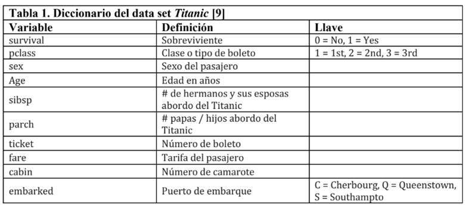

**2.1 Considera la variable fare, ¿de qué tipo es?**

es un atributo numérico de tipo escala de proporción

**2.2 Abre el libro Titanic en Excel o el manejador de hoja de cálculo que prefieras. Como aplicarás algunas técnicas de preprocesamiento a ese data set, crea una copia para que trabajes con ella.**

**2.3 Crea una nueva hoja y copia la columna fare a la misma. Utiliza la técnica de agregación de datos para reducir la variable fare a los tres grupos siguientes: 0-150, 151-300, 301-513. Con la reducción anterior debes tener una tabla como la siguiente:**

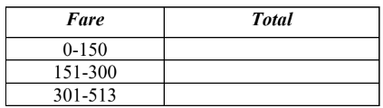

```r
library(readxl)
library(knitr)
titanic_DF <- read_excel("C:/Users/juan_/OneDrive - Universidad de Colima/Escritorio/6to/practica 3 Técnicas para transformación de datos - MdD/Titanic.xlsx")

fare = titanic_DF$Fare
r1 = 0
r2 = 0
r3 = 0

for(i in fare){
  if(i >= 0 && i <= 150){
    r1 = r1 + 1
  }
  if(i >= 151 && i <= 300){
    r2 = r2 + 1
  }
  if(i >= 301 && i <= 513){
    r3 = r3 + 1
  }
}

frecuency = c(r1, r2, r3)
fare_tag = c("0-150", "151-300", "301-513")

fare_frequency <- data.frame(Fare = fare_tag,Total =  frecuency)
knitr::kable(fare_frequency)
```

| Fare | Total |
| --- | --- |
| 0-150 | 862 |
| 151-300 | 26 |
| 301-513 | 3 |

```r
c = 0
for(i in fare_frequency$Total){
  c = c + i
}
print(length(fare))
```

```
## [1] 891
```

```r
print(c)
```

```
## [1] 891
```

**2.4 Ahora, considera la misma columna fare en la hoja de cálculo. Utiliza la técnica de normalización para transformar los datos de esa columna a datos normalizados entre 0 y 100. Al lado de la columna fare crea una columna llamada fare_norm, que muestre el valor normalizado de la columna fare.**

```r
#normalization
fare_norm <- c()
for(x in fare){
  d = (x - min(fare)) / (max(fare) - min(fare)) * 100
  fare_norm <- append(fare_norm, d)
}

#adding the fare_norm column
titanic_DF = cbind(titanic_DF, Fare_Norm = fare_norm)

#code by Ken Williams, GitHub: https://github.com/kenahoo
moveme <- function (invec, movecommand) {
  movecommand <- lapply(strsplit(strsplit(movecommand, ";")[[1]],
                                 ",|\\s+"), function(x) x[x != ""])
  movelist <- lapply(movecommand, function(x) {
    Where <- x[which(x %in% c("before", "after", "first",
                              "last")):length(x)]
    ToMove <- setdiff(x, Where)
    list(ToMove, Where)
  })
  myVec <- invec
  for (i in seq_along(movelist)) {
    temp <- setdiff(myVec, movelist[[i]][[1]])
    A <- movelist[[i]][[2]][1]
    if (A %in% c("before", "after")) {
      ba <- movelist[[i]][[2]][2]
      if (A == "before") {
        after <- match(ba, temp) - 1
      }
      else if (A == "after") {
        after <- match(ba, temp)
      }
    }
    else if (A == "first") {
      after <- 0
    }
    else if (A == "last") {
      after <- length(myVec)
    }
    myVec <- append(temp, values = movelist[[i]][[1]], after = after)
  }
  myVec
}

#moving the Fare:Norm position
titanic_DF[moveme(names(titanic_DF), "Fare_Norm after Fare")]
```

| PassengerId | Survived | Pclass | Name | Sex | Age | SibSp | Parch | Ticket | Fare | Fare_Norm | Cabin | Embarked |
| --- | --- | --- | --- | --- | --- | --- | --- | --- | --- | --- | --- | --- |
| 1 | 0 | 3 | Braund, Mr. Owen Harris | male | 22.00 | 1 | 0 | A/5 21171 | 7.2500 | 1.4151058 | NA | S |
| 2 | 1 | 1 | Cumings, Mrs. John Bradley (Florence Briggs Thayer) | female | 38.00 | 1 | 0 | PC 17599 | 71.2833 | 13.9135735 | C85 | C |
| 3 | 1 | 3 | Heikkinen, Miss. Laina | female | 26.00 | 0 | 0 | STON/O2. 3101282 | 7.9250 | 1.5468570 | NA | S |
| 4 | 1 | 1 | Futrelle, Mrs. Jacques Heath (Lily May Peel) | female | 35.00 | 1 | 0 | 113803 | 53.1000 | 10.3644297 | C123 | S |
| 5 | 0 | 3 | Allen, Mr. William Henry | male | 35.00 | 0 | 0 | 373450 | 8.0500 | 1.5712554 | NA | S |
| 6 | 0 | 3 | Moran, Mr. James | male | NA | 0 | 0 | 330877 | 8.4583 | 1.6509502 | NA | Q |
| 7 | 0 | 1 | McCarthy, Mr. Timothy J | male | 54.00 | 0 | 0 | 17463 | 51.8625 | 10.1228858 | E46 | S |
| 8 | 0 | 3 | Palsson, Master. Gosta Leonard | male | 2.00 | 3 | 1 | 349909 | 21.0750 | 4.1135660 | NA | S |
| 9 | 1 | 3 | Johnson, Mrs. Oscar W (Elisabeth Vilhelmina Berg) | female | 27.00 | 0 | 2 | 347742 | 11.1333 | 2.1730754 | NA | S |
| 10 | 1 | 2 | Nasser, Mrs. Nicholas (Adele Achem) | female | 14.00 | 1 | 0 | 237736 | 30.0708 | 5.8694293 | NA | C |

[output cut: 881 more lines]

**Una vez creada la nueva columna, calcula la sumatoria de ambas columnas y analiza los resultados, con respecto a las sumatorias de ambas columnas**

```r
print(sum(titanic_DF$Fare))
```

```
## [1] 28693.95
```

```r
print(sum(titanic_DF$Fare_Norm))
```

```
## [1] 5600.686
```

**¿qué provocó la normalización?**

La sumatoria total se redujo aproximadamente 5 veces, debido a que el rango de la columna orignal llegaba hasta 500+, una vez normalizados los datos, no quedaron datos mayores a 100

**2.5 Ahora accede al entorno de R.**

xd

**2.6 Importa el archivo de hoja de cálculo Titanic. Utiliza la técnica de reducción de cantidad creando un histograma de frecuencias de la variable fare. Crea un gráfico del histograma de frecuencias.**

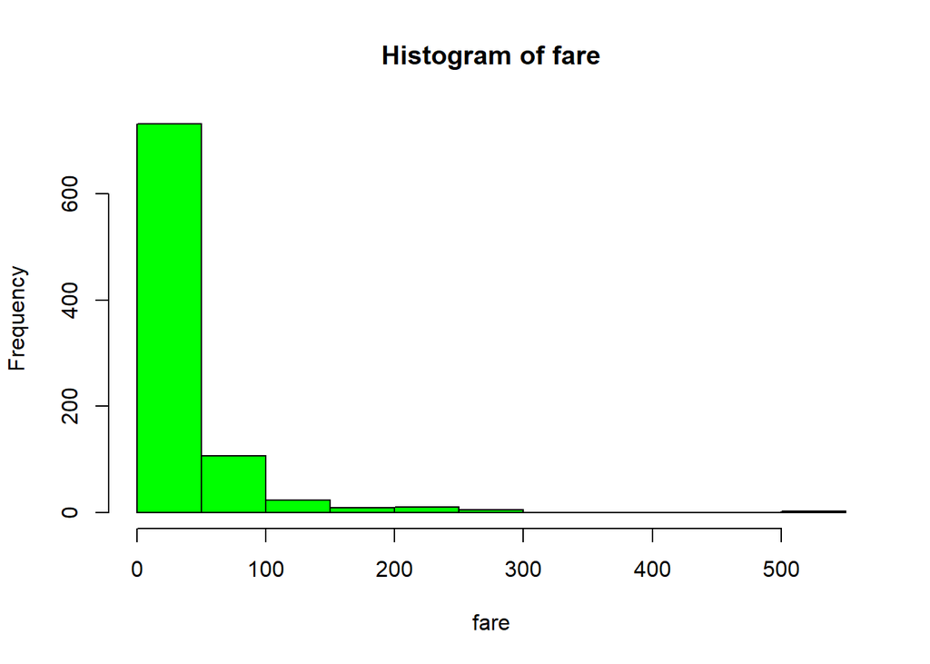

```r
#histograma
hist(fare, col="green")
```

## Conclusiones de la práctica

En está práctica realicé varias técnicas para analizar el vector Fare, como su frecuencia y la trasnformación de cada registro (solo columna Fare) en un dato normalizado. A su vez también aprendí como usar las R Notebooks en R Studio y como desplegarlas en GitHub Pages